# 20251014 work

오늘의 목표: 기후 희귀성에 따른 희귀 종의 분포 확인하기

일단 가지고 있는 기후변수

| 변수명 | 설명 |
| --- | --- |
| BIO1 | 연평균 기온 (Annual Mean Temperature) |
| BIO2 | 월별 일교차 평균 (Mean Diurnal Range, 월별 최대기온 - 최소기온의 평균) |
| BIO3 | 등온성 (Isothermality, BIO2/BIO7 ×100) |
| BIO4 | 기온 연변동성 (Temperature Seasonality, 표준편차 ×100) |
| BIO5 | 가장 더운 달의 최고 기온 (Max Temperature of Warmest Month) |
| BIO6 | 가장 추운 달의 최저 기온 (Min Temperature of Coldest Month) |
| BIO7 | 연중 기온 범위 (Temperature Annual Range, BIO5 - BIO6) |
| BIO8 | 강수량이 가장 많은 3개월의 평균 기온 (Mean Temperature of Wettest Quarter) |
| BIO9 | 강수량이 가장 적은 3개월의 평균 기온 (Mean Temperature of Driest Quarter) |
| BIO10 | 가장 더운 3개월의 평균 기온 (Mean Temperature of Warmest Quarter) |
| BIO11 | 가장 추운 3개월의 평균 기온 (Mean Temperature of Coldest Quarter) |
| BIO12 | 연간 강수량 (Annual Precipitation) |
| BIO13 | 월별 최다 강수월의 강수량 (Precipitation of Wettest Month) |
| BIO14 | 월별 최소 강수월의 강수량 (Precipitation of Driest Month) |
| BIO15 | 강수 연변동성 (Precipitation Seasonality, 변동계수) |
| BIO16 | 강수량이 가장 많은 3개월간의 강수량 (Precipitation of Wettest Quarter) |
| BIO17 | 강수량이 가장 적은 3개월간의 강수량 (Precipitation of Driest Quarter) |
| BIO18 | 가장 더운 3개월간의 강수량 (Precipitation of Warmest Quarter) |
| BIO19 | 가장 추운 3개월간의 강수량 (Precipitation of Coldest Quarter) |
| GSP | 생장기 누적 강수량 |
| GST | 생장기 평균 기온 |
| NPP | 총 1차 생산량 |

이 중 어떤 것을 사용할까? 우리나라 육상 기준으로 나눈 후, 관련도가 높은 것을 제거하자.

먼저 우리나라 땅과 기후 자료를 불러오자.

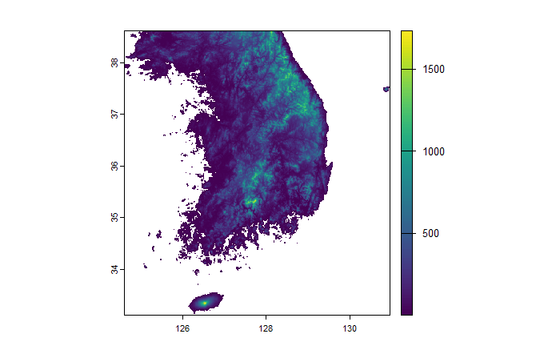

```r
# 우리나라에 해당하는 고도 자료 불러오기
library(terra)

elev <- rast("./data/terrestrial_250509.tif")

plot(elev)
```

```r
# 기후 자료 불러오기
climlist <- list.files("./data/climate_chelsa_1981-2010", pattern = "\\.tif$", full.names = TRUE)
clim <- rast(climlist)

names(clim) <- c("bio1", "bio10", "bio11", "bio12", "bio13", "bio14", "bio15", "bio16", "bio17", "bio18", "bio19", "bio2", "bio3", "bio4", "bio5", "bio6", "bio7", "bio8", "bio9", "gsp", "gst", "npp")

names(elev) <- c("elevation")
```

좌표계를 m로 계산할 수 있는 5179로 바꾸고, 기후 변수들을 우리나라 모양에 맞게 자르자.

```r
# 좌표계 지정하기
library(terra)

target_crs <- "EPSG:5179"

# 우리나라 모양으로 기후 변수 자르기
cropped_clim <- crop(clim, elev)

masked_clim <- mask(cropped_clim, elev)
masked_clim_5179 <- project(masked_clim, target_crs, res = 1000)

summary(masked_clim_5179)
```

```
      bio1            bio10           bio11            bio12            bio13           bio14
 Min.   : 4.485   Min.   :16.44   Min.   :-8.281   Min.   : 776.9   Min.   :195.8   Min.   :10.30
 1st Qu.:11.060   1st Qu.:22.68   1st Qu.:-1.975   1st Qu.:1263.9   1st Qu.:283.2   1st Qu.:19.30
 Median :12.125   Median :23.52   Median :-0.026   Median :1392.8   Median :323.1   Median :23.74
 Mean   :11.999   Mean   :23.23   Mean   :-0.010   Mean   :1419.3   Mean   :332.9   Mean   :25.34
 3rd Qu.:13.326   3rd Qu.:24.16   3rd Qu.: 1.736   3rd Qu.:1556.5   3rd Qu.:377.1   3rd Qu.:29.86
 Max.   :16.450   Max.   :25.75   Max.   : 8.450   Max.   :3289.4   Max.   :617.5   Max.   :94.12
 NA's   :64813    NA's   :64813   NA's   :64813    NA's   :64813    NA's   :64813   NA's   :64813
     bio15            bio16            bio17            bio18            bio19             bio2
 Min.   : 30.99   Min.   : 472.9   Min.   : 34.63   Min.   : 460.8   Min.   : 34.63   Min.   : 1.800
 1st Qu.: 78.54   1st Qu.: 715.6   1st Qu.: 68.92   1st Qu.: 702.8   1st Qu.: 68.99   1st Qu.: 6.796
 Median : 85.64   Median : 804.4   Median : 87.91   Median : 783.5   Median : 88.46   Median : 9.016
 Mean   : 86.47   Mean   : 817.0   Mean   : 91.55   Mean   : 794.7   Mean   : 92.59   Mean   : 7.910
 3rd Qu.: 95.79   3rd Qu.: 903.5   3rd Qu.:110.33   3rd Qu.: 875.6   3rd Qu.:111.27   3rd Qu.: 9.400
 Max.   :109.50   Max.   :1526.0   Max.   :347.10   Max.   :1521.5   Max.   :373.34   Max.   :10.500
 NA's   :64813    NA's   :64813    NA's   :64813    NA's   :64813    NA's   :64813    NA's   :64813
      bio3            bio4             bio5            bio6              bio7            bio8
 Min.   :0.080   Min.   : 648.0   Min.   :20.29   Min.   :-17.744   Min.   :21.40   Min.   :15.82
 1st Qu.:0.212   1st Qu.: 865.2   1st Qu.:26.39   1st Qu.: -9.801   1st Qu.:31.65   1st Qu.:22.29
 Median :0.244   Median : 917.4   Median :27.50   Median : -6.566   Median :34.65   Median :23.14
 Mean   :0.229   Mean   : 903.5   Mean   :27.26   Mean   : -6.615   Mean   :33.88   Mean   :22.88
 3rd Qu.:0.259   3rd Qu.: 964.5   3rd Qu.:28.35   3rd Qu.: -3.965   3rd Qu.:37.20   3rd Qu.:23.85
 Max.   :0.307   Max.   :1055.3   Max.   :30.08   Max.   :  5.950   Max.   :42.53   Max.   :25.34
 NA's   :64813   NA's   :64813    NA's   :64813   NA's   :64813     NA's   :64813   NA's   :64813
      bio9             gsp              gst             npp
 Min.   :-8.281   Min.   : 733.1   Min.   :11.90   Min.   : 942.3
 1st Qu.:-1.950   1st Qu.:1207.2   1st Qu.:14.55   1st Qu.:1460.9
 Median : 0.050   Median :1320.4   Median :15.37   Median :1572.8
 Mean   : 0.256   Mean   :1342.5   Mean   :15.19   Mean   :1555.8
 3rd Qu.: 2.071   3rd Qu.:1474.2   3rd Qu.:15.92   3rd Qu.:1660.7
 Max.   : 9.603   Max.   :2975.4   Max.   :16.65   Max.   :1965.4
 NA's   :64813    NA's   :64813    NA's   :64813   NA's   :64813
```

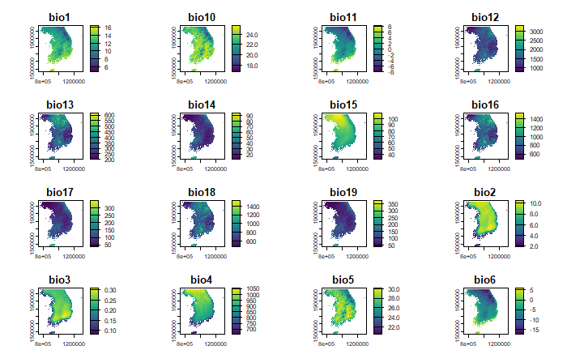

```r
plot(masked_clim_5179)
```

```r
NA
NA
```

그림이 17번째부터 22번째까지는 안 나오기는 하는데 일단 있긴 함..

22개 변수를 다 쓸 수는 없으므로 변수 추리기 - 먼저 다중공선성으로 판단하기

```r
library(usdm)

clm_df <- as.data.frame(masked_clim_5179, na.rm = TRUE)

# VIF 계산
vif_result <- vif(clm_df)
print(vif_result)
```

| Variables | VIF |
| --- | --- |
| bio1 | 1.290291e+03 |
| bio10 | 8.304521e+02 |
| bio11 | 5.424920e+03 |
| bio12 | 8.715487e+02 |
| bio13 | 8.741312e+01 |
| bio14 | 6.872022e+01 |
| bio15 | 7.421443e+01 |
| bio16 | 2.766198e+02 |
| bio17 | 2.004849e+02 |
| bio18 | 8.234830e+01 |

[output cut: 12 more lines]

```r
vif_filtered <- vifstep(clm_df, th = 10)  # threshold는 필요시 조정

# 선택된 변수 이름 확인
selected_vars <- vif_filtered@results$Variables
print(selected_vars)
```

```
[1] "bio14" "bio15" "bio3"  "bio8"  "gsp"   "gst"   "npp"
```

vif 값 10을 기준으로 했을 때 걸러진 값들: “bio14” “bio15” “bio3” “bio8” “gsp” “gst” “npp”

1차로 걸러진 7개 변수의 Pearson correlation 확인하기(0.7 이상은 제거)

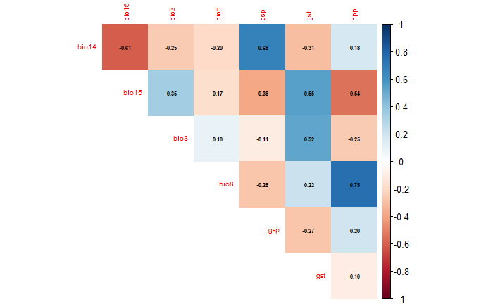

```r
# 선택된 변수들만 추출한 SpatRaster 생성
clm_var_selected <- subset(masked_clim_5179, selected_vars)

# 상관관계 그림 그리기
clm_df_selected <- as.data.frame(clm_var_selected, na.rm = TRUE)

library(corrplot)

corr_matrix <- cor(clm_df_selected, use = "complete.obs")

corrplot(
  corr_matrix,
  method = "color",        # 색상으로 시각화
  tl.cex = 0.6,            # 변수 이름 크기
  addCoef.col = "black",   # 상관계수 텍스트 색
  number.cex = 0.5,        # 상관계수 숫자 크기
  type = "upper",          # 위쪽 삼각형만 표시 (선택 사항)
  diag = FALSE             # 대각선 제거 (선택 사항)
)
```

```r
corr_abs <- abs(corr_matrix)

#대각선 제거 (자기 자신과의 상관은 1이므로 제외)
diag(corr_abs) <- 0

library(caret)

high_corr_idx <- findCorrelation(corr_abs, cutoff = 0.7, verbose = TRUE)
```

```
Compare row 7  and column  4 with corr  0.753
  Means:  0.337 vs 0.342 so flagging column 4
All correlations <= 0.7
```

```r
#제거 대상 변수 이름
remove_vars <- colnames(corr_abs)[high_corr_idx]

#제거 후 남길 변수만 선택
kept_vars <- setdiff(names(clm_df_selected), remove_vars)
print(kept_vars)
```

```
[1] "bio14" "bio15" "bio3"  "gsp"   "gst"   "npp"
```

Pearson 상관계수로 걸러진 값들: “bio14” “bio15” “bio3” “gsp” “gst” “npp” (bio8만 사라짐)

총 6개 기후 변수로 다시 상관관계 그래프 확인하기

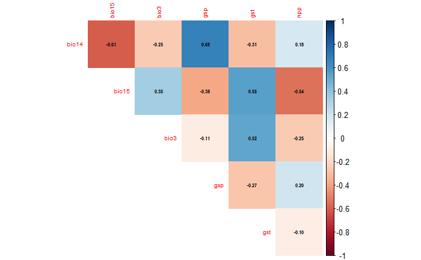

```r
#데이터프레임 필터링
clm_df_filtered <- clm_df[, kept_vars]

corr_matrix_f <- cor(clm_df_filtered, use = "complete.obs")

corrplot(
  corr_matrix_f,
  method = "color",        # 색상으로 시각화
  tl.cex = 0.6,            # 변수 이름 크기
  addCoef.col = "black",   # 상관계수 텍스트 색
  number.cex = 0.5,        # 상관계수 숫자 크기
  type = "upper",          # 위쪽 삼각형만 표시 (선택 사항)
  diag = FALSE             # 대각선 제거 (선택 사항)
)
```

```
class(object) <- "environment"에서 경고가 발생했습니다 :
  "environment"에 class(x)를 설정하는 것은 속성을 NULL로 변경하는 것이므로, 결과는 더이상 S4 객체가 아닙니다
```

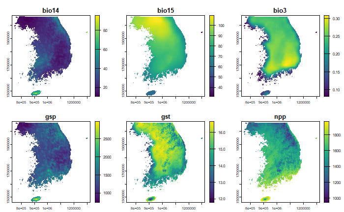

```r
#SpatRaster에서도 동일하게 필터링
clm_var_filter <- subset(masked_clim_5179, kept_vars)

plot(clm_var_filter)
```